# Assignment 3 - Indirect Effects

```r
library(haven)
library(lavaan)
library(semPlot)
library(tidyverse)
```

```r
setwd('~/Google_Drive/courses/Structural_Equation_Modeling/assignments/assignment_03/')
getwd()
```

```
[1] "/Users/haroonpopal/Google_Drive/courses/Structural_Equation_Modeling/assignments/assignment_03"
```

## Import Human Connectome Project (HCP) dataset

This dataset is the Human Connectome Project data for healthy young adults. I will be looking at neuroticism from the NEO-PI, a measure of theory of mind, a measure of friendship, and a measure of angry affect.

```r
hw3_df <- read.csv('../unrestricted_hspopal_9_9_2019_22_40_57.csv')
```

## Specify the linear model: AngAffect_Unadj (angry affect) as DV

```r
h3_m1 <- lm(AngAffect_Unadj ~ Social_Task_Perc_TOM + NEOFAC_N, hw3_df)
coefficients(summary(h3_m1))
```

```
                        Estimate Std. Error    t value      Pr(>|t|)
(Intercept)          38.34487381 1.41905375 27.0214386 1.858542e-122
Social_Task_Perc_TOM  0.00963914 0.02625342  0.3671575  7.135756e-01
NEOFAC_N              0.53930102 0.03011597 17.9074750  8.972740e-63
```

```r
h3_m2 <- lm(Friendship_Unadj ~ Social_Task_Perc_TOM + NEOFAC_N + AngAffect_Unadj, hw3_df)
coefficients(summary(h3_m2))
```

```
                        Estimate Std. Error    t value      Pr(>|t|)
(Intercept)          65.12280204 2.15595803 30.2059693 1.182861e-144
Social_Task_Perc_TOM -0.02400186 0.03062321 -0.7837801  4.333464e-01
NEOFAC_N             -0.32071022 0.04014244 -7.9893060  3.559630e-15
AngAffect_Unadj      -0.17046932 0.03602934 -4.7314034  2.535182e-06
```

```r
#round(coefficients(summary(cl3_m2)), 3)
```

## Specify the full model

```r
h3_m3 <- 'Friendship_Unadj ~ Social_Task_Perc_TOM + NEOFAC_N + AngAffect_Unadj
           AngAffect_Unadj ~ Social_Task_Perc_TOM + NEOFAC_N'
# Estimate the model
h3_m3_fit <- sem(h3_m3, hw3_df)
summary(h3_m3_fit)
```

```
lavaan 0.6-5 ended normally after 15 iterations

  Estimator                                         ML
  Optimization method                           NLMINB
  Number of free parameters                          7

                                                  Used       Total
  Number of observations                          1051        1206

Model Test User Model:

  Test statistic                                 0.000
  Degrees of freedom                                 0

Parameter Estimates:

  Information                                 Expected
  Information saturated (h1) model          Structured
  Standard errors                             Standard

Regressions:
                     Estimate  Std.Err  z-value  P(>|z|)
  Friendship_Unadj ~
    Scl_Tsk_Pr_TOM     -0.024    0.031   -0.785    0.432
    NEOFAC_N           -0.321    0.040   -8.005    0.000
    AngAffect_Undj     -0.170    0.036   -4.740    0.000
  AngAffect_Unadj ~
    Scl_Tsk_Pr_TOM      0.010    0.026    0.368    0.713
    NEOFAC_N            0.539    0.030   17.933    0.000

Variances:
                   Estimate  Std.Err  z-value  P(>|z|)
   .Friendshp_Undj   70.514    3.076   22.924    0.000
   .AngAffect_Undj   51.882    2.263   22.924    0.000
```

# Indirect Effect

## Fit the model

```r
hw3_m4 <- '#direct effect
           Friendship_Unadj ~ c*NEOFAC_N

           #DV ON Mediator
           Friendship_Unadj ~ b*AngAffect_Unadj

           #M ON IV
           AngAffect_Unadj ~ a*NEOFAC_N
           # indirect effect (a*b)
           ab := a*b

           # total effect
           total := c + (a*b)'
hw3_m4_fit <- sem(hw3_m4, hw3_df)
# Examine model parameters
parameterEstimates(hw3_m4_fit, standardized = T)
```

|  | lhs | op | rhs | label | est | se | z | pvalue | ci.lower | ci.upper | std.lv | std.all | std.nox |
| --- | --- | --- | --- | --- | --- | --- | --- | --- | --- | --- | --- | --- | --- |
| 1 | Friendship_Unadj | ~ | NEOFAC_N | c | -0.309 | 0.038 | -8.153 | 0 | -0.384 | -0.235 | -0.309 | -0.250 | -0.034 |
| 2 | Friendship_Unadj | ~ | AngAffect_Unadj | b | -0.182 | 0.033 | -5.455 | 0 | -0.247 | -0.116 | -0.182 | -0.168 | -0.168 |
| 3 | AngAffect_Unadj | ~ | NEOFAC_N | a | 0.548 | 0.029 | 18.986 | 0 | 0.491 | 0.604 | 0.548 | 0.481 | 0.065 |
| 4 | Friendship_Unadj | ~~ | Friendship_Unadj |  | 72.213 | 2.951 | 24.474 | 0 | 66.430 | 77.996 | 72.213 | 0.869 | 0.869 |
| 5 | AngAffect_Unadj | ~~ | AngAffect_Unadj |  | 54.356 | 2.221 | 24.474 | 0 | 50.003 | 58.708 | 54.356 | 0.769 | 0.769 |
| 6 | NEOFAC_N | ~~ | NEOFAC_N |  | 54.483 | 0.000 | NA | NA | 54.483 | 54.483 | 54.483 | 1.000 | 54.483 |
| 7 | ab | := | a*b | ab | -0.100 | 0.019 | -5.243 | 0 | -0.137 | -0.062 | -0.100 | -0.081 | -0.011 |
| 8 | total | := | c+(a*b) | total | -0.409 | 0.034 | -12.141 | 0 | -0.475 | -0.343 | -0.409 | -0.331 | -0.045 |

### Set seed for replicability

```r
set.seed(8675309)
```

## Fit the bootstrapped model

```r
hw3_m4_fit_boot <- sem(hw3_m4, hw3_df, se = "bootstrap", bootstrap = 1000)
```

```
lavaan WARNING: the optimizer warns that a solution has NOT been found!lavaan WARNING: the optimizer warns that a solution has NOT been found!lavaan WARNING: only 998 bootstrap draws were successful
```

```r
# Examine the bootstrapped model parameters
parameterEstimates(hw3_m4_fit_boot, standardized = T, boot.ci.type = "bca.simple")
```

|  | lhs | op | rhs | label | est | se | z | pvalue | ci.lower | ci.upper | std.lv | std.all | std.nox |
| --- | --- | --- | --- | --- | --- | --- | --- | --- | --- | --- | --- | --- | --- |
| 1 | Friendship_Unadj | ~ | NEOFAC_N | c | -0.309 | 0.042 | -7.317 | 0 | -0.389 | -0.231 | -0.309 | -0.250 | -0.034 |
| 2 | Friendship_Unadj | ~ | AngAffect_Unadj | b | -0.182 | 0.036 | -5.072 | 0 | -0.252 | -0.113 | -0.182 | -0.168 | -0.168 |
| 3 | AngAffect_Unadj | ~ | NEOFAC_N | a | 0.548 | 0.031 | 17.920 | 0 | 0.489 | 0.608 | 0.548 | 0.481 | 0.065 |
| 4 | Friendship_Unadj | ~~ | Friendship_Unadj |  | 72.213 | 2.977 | 24.261 | 0 | 67.013 | 78.729 | 72.213 | 0.869 | 0.869 |
| 5 | AngAffect_Unadj | ~~ | AngAffect_Unadj |  | 54.356 | 2.507 | 21.678 | 0 | 49.620 | 59.420 | 54.356 | 0.769 | 0.769 |
| 6 | NEOFAC_N | ~~ | NEOFAC_N |  | 54.483 | 0.000 | NA | NA | 54.483 | 54.483 | 54.483 | 1.000 | 54.483 |
| 7 | ab | := | a*b | ab | -0.100 | 0.020 | -4.942 | 0 | -0.140 | -0.062 | -0.100 | -0.081 | -0.011 |
| 8 | total | := | c+(a*b) | total | -0.409 | 0.037 | -11.034 | 0 | -0.482 | -0.340 | -0.409 | -0.331 | -0.045 |

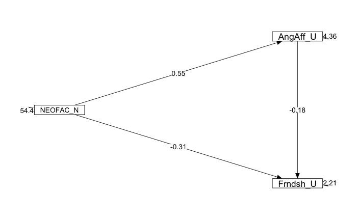

```r
semPaths(hw3_m4_fit_boot, "path", whatLabels = "est",
         edge.label.cex = 1, rotation = 2, intercepts = FALSE, residuals = TRUE, curve = 1,
         curvature = 3, nCharNodes = 8, sizeMan = 16, sizeMan2 = 3, optimizeLatRes = TRUE, edge.color = "#000000")
```

# Results and Discussion

Models were estimated using the lavaan package available in R. Due to the inclusion of indirect effects in the model, we relied on bias corrected bootstrapping, with 1000 bootstrap resamples, to evaluate the significance of those paths. The model was specified such that there were direct effects of neuroticism and angry affect on a measure of friendship. There were also indirect effects specified, such that the influence of neuroticism on friendship were hypothesized to operate through angry affect.

We found that neuroticism and angry affect was associated with friendship (b = -.31, SE = .04, z = -7.31, p < .001; b = -.18, SE = .04, z = -5.07, p < .001). We also found that neuroticism was associated with angry affect (b = .55, SE = .03, z = 17.92, p < .001), We found a significant indirect of neuroticism on friendship through angry affect (b = -.10, 95% CI = -.14, -.06).